# project3finished

Vincent Barletta

2023-05-17

```r
db = dbConnect(SQLite(), "stats.stackexchange.db")
dbListTables(db)
```

```
##  [1] "BadgeClassMap"         "Badges"                "CloseReasonMap"
##  [4] "Comments"              "LinkTypeMap"           "PostHistory"
##  [7] "PostHistoryTypeId"     "PostLinks"             "PostTypeIdMap"
## [10] "Posts"                 "TagPosts"              "Users"
## [13] "VoteTypeMap"           "Votes"                 "a_time"
## [16] "accepted_answer_count" "answer_count"          "answer_info"
## [19] "creationdates"         "distinct_tags"         "first_accepted"
## [22] "first_answer"          "fullresults_qa"        "intermediary"
## [25] "medal_counts"          "medal_test_table"      "numbefore"
## [28] "q_time"                "question_count"        "question_info"
## [31] "tag_count"             "tag_count2"            "tag_count3"
## [34] "tag_count5"            "tag_count6"            "tag_count7"
## [37] "tag_count8"            "top_user_info"         "users_questions"
```

I would like to preface this by saying I have submitted this as an HTML document only because I was having LaTeX issues with outputting as a PDF.

Question 1

1. How many users are there?

For this question, we will simply count the number of distinct IDs from the user table. Typically, databases will have one-to-one correspondence between Id and User accounts. We first will check to make sure that there is not two of the same ID in the database; this shouldn’t occur since it is the primary key, but it is good practice to check.

```r
dbGetQuery(db, "SELECT Id, COUNT(*) FROM Users GROUP BY Id HAVING COUNT(*) > 1")
```

```
## [1] Id       COUNT(*)
## <0 rows> (or 0-length row.names)
```

```r
print("This gives no rows, meaning there are no IDs that occur twice in the table.")
```

```
## [1] "This gives no rows, meaning there are no IDs that occur twice in the table."
```

```r
dbGetQuery(db, "SELECT COUNT(Distinct Id) FROM Users")
```

```
##   COUNT(Distinct Id)
## 1             321677
```

There are 321677 unique users registered on the stats stack exchange website.

Question 2

2. How many users joined since 2020? (Hint: Convert the CreationDate to a year.)

```r
dbGetQuery(db, "SELECT COUNT(Distinct Id) FROM Users
           WHERE CAST(CreationDate AS DATE) >= 2020")
```

```
##   COUNT(Distinct Id)
## 1             100796
```

100,796 new users have joined since 2020. We simply cast the CreationDate as DATE and only collect records when the year is >= 2020.

Question 3

3. How many users joined each year? Describe this with a plot, commenting on any anomalies.

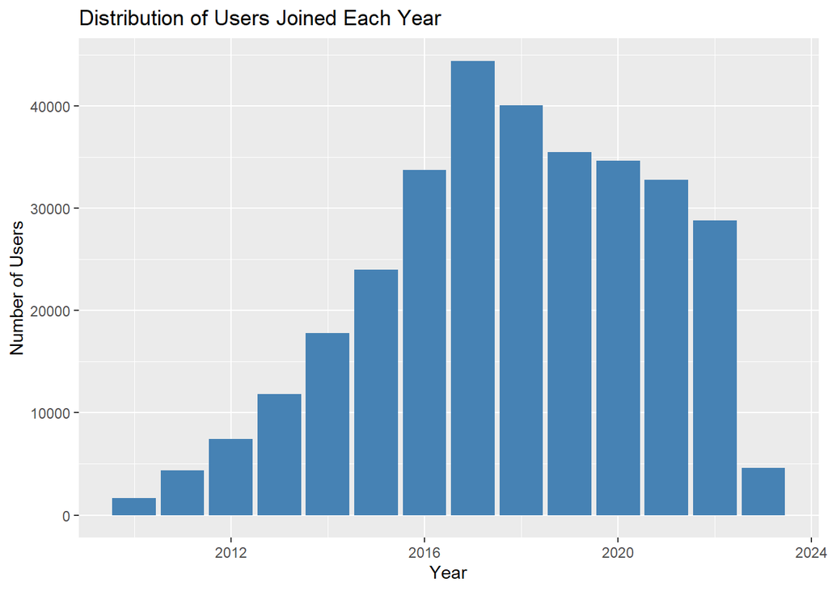

```r
joined_distribution <- dbGetQuery(db, "SELECT CAST(CreationDate AS DATE) as Year, COUNT(Distinct Id) as Users FROM Users GROUP BY CAST(CreationDate AS DATE)")

ggplot(joined_distribution, aes(x = Year, y = Users)) +
  geom_bar(stat = "identity", fill = "steelblue") +
  labs(title = "Distribution of Users Joined Each Year",
       x = "Year", y = "Number of Users")
```

Here, we can see that 2017 is the peak of all users joining. The distribution grows exponentially from the website’s creation date in 2010 up until 2017 before steadily decreasing after. 2023 has very few entries as the year is still not finished.

Question 4

4. How many different types of posts are there in the Posts table? Get the description of the types from the PostTypeIdMap table. In other words, create a table with the description of each post type and the number of posts of that type, and arrange it from most to least occurrences.

```r
post_types <- dbGetQuery(db, "SELECT DISTINCT(PostTypeId) as PostTypeId, i.value as PostTypeName, COUNT(*) FROM Posts as p, PostTypeIdMap as i where i.id = p.PostTypeId GROUP BY PostTypeId ORDER BY COUNT(*) DESC")

post_types
```

```
##   PostTypeId                                                 PostTypeName
## 1          1                                                     Question
## 2          2                                                       Answer
## 3          5                                                     Tag wiki
## 4          4                                             Tag wiki excerpt
## 5          6                                         Moderator nomination
## 6          3                                            Orphaned tag wiki
## 7          7 Wiki placeholder (seems to only be the election description)
##   COUNT(*)
## 1   204370
## 2   197928
## 3     1444
## 4     1444
## 5       23
## 6        6
## 7        5
```

Noticeably, there are no posts with PostTypeID = 8, the privilege wiki. According to stackexchange’s metadata description, these posts are, “questions asking us to recommend or find a tool, library or favorite off-site resource are off-topic for Stack Overflow as they tend to attract opinionated answers and spam. Instead, describe the problem and what has been done so far to solve it.”

Question 5

5. How many posted questions are there?

We can use our table that we created for Question 4. Since Question is the most common Post type, we just take the top result from this table.

```r
post_types[1,]
```

```
##   PostTypeId PostTypeName COUNT(*)
## 1          1     Question   204370
```

There are 204,370 posted questions.

Question 6

6. What are the top 50 most common tags on questions? For each of the top 50 tags on questions, how many questions are there for each tag.

```r
top50tags <-dbGetQuery(db, "SELECT Tag, COUNT(*) as Count FROM TagPosts GROUP BY Tag ORDER BY COUNT(*) DESC LIMIT 50")
head(top50tags)
```

```
##                  Tag Count
## 1                  r 28495
## 2         regression 28146
## 3   machine-learning 19355
## 4        time-series 13745
## 5        probability 11894
## 6 hypothesis-testing 10091
```

```r
tail(top50tags)
```

```
##                      Tag Count
## 45              modeling  2501
## 46            references  2451
## 47 multivariate-analysis  2430
## 48          econometrics  2422
## 49           interaction  2421
## 50          linear-model  2412
```

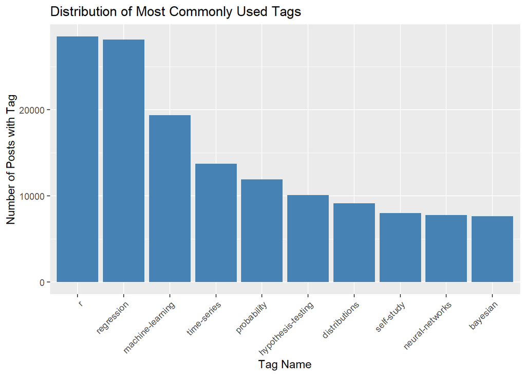

```r
top_10_tags = head(top50tags, n = 10)

ggplot(top_10_tags, aes(x = reorder(Tag, -Count), y = Count)) +
  geom_bar(stat = "identity", fill = "steelblue") +
  labs(title = "Distribution of Most Commonly Used Tags",
       x = "Tag Name", y = "Number of Posts with Tag") +
  theme(axis.text.x = element_text(angle = 45, hjust = 1))
```

Here, we group each tag by name and calculate how many appearances there are of each tag across all questions. The ‘R’ tag has by far the most appearances, with 28495 questions. Regression is not far behind with 28146 appearances. The rest of the top 6 are machine-learning, time-series, probability, and hypothesis-testing. The 45th to 50th ranked tags are modeling, references, multivariate-analysis, econometrics, interaction, and linear-model.

7. How many tags are in most questions?

```r
dbSendStatement(db, "CREATE VIEW tag_count10 as SELECT Id, COUNT(Tag) as Count FROM TagPosts GROUP BY Id")
```

```
## <SQLiteResult>
##   SQL  CREATE VIEW tag_count10 as SELECT Id, COUNT(Tag) as Count FROM TagPosts GROUP BY Id
##   ROWS Fetched: 0 [complete]
##        Changed: 0
```

```r
tag_freq <- dbGetQuery(db, "SELECT Count, COUNT(Count) as Frequency FROM tag_count10 GROUP BY Count ORDER BY COUNT(Count) DESC")
tag_freq
```

```
##   Count Frequency
## 1     3     59782
## 2     2     49278
## 3     4     43249
## 4     5     31898
## 5     1     20163
```

Most questions have three tags. A question cannot have more than 5 tags, and has to have at least one tag. 90.1% of questions have at least two tags.

8. How many answers are there?

```r
post_types[2,]
```

```
##   PostTypeId PostTypeName COUNT(*)
## 2          2       Answer   197928
```

According to the post_types table we created for Question 4, any post flagged with PostTypeId = 2 is an answer. By counting these posts, we see that there are 197,928 Answers posted.

9. What’s the most recent question (by date-time) in the Posts table? • Find it on the stats.exchange.com Web site and provide the URL. • How would we map a question in the Posts table to the corresponding SO URL?

While we could go through the trouble of converting the CreationDate variable into a Date, an easier shortcut is to simply order by the Post Id in descending order, as the last ID will be the most recent post.

```r
dbGetQuery(db, "SELECT * FROM Posts WHERE PostTypeId = 1 ORDER BY Id DESC LIMIT 1")
```

```
##       Id PostTypeId AcceptedAnswerId            CreationDate Score ViewCount
## 1 608405          1                  2023-03-05T05:10:18.393     0         6
##                                                                                                                                                                                                                                                                                                          …
## 1 <p>Are there any methods that combine VI and MCMC? If it exists, why isn’t it used prominently over techniques such as NUTS or other VIs.</p>\\\\n<p>Another question that just popped up in my head why is HMC sampling parallelizable after stationary? Is it related with some kind of sequential bo…
##   OwnerUserId        LastActivityDate
## 1      382402 2023-03-05T05:10:18.393
##                                                                         Title
## 1 Are there any papers or methods that combine mcmc and variational inference
##                                                                        Tags
## 1 <markov-chain-montecarlo><variational-inference><hamiltonian-monte-carlo>
##   AnswerCount CommentCount ContentLicense LastEditorDisplayName LastEditDate
## 1           0            0   CC BY-SA 4.0
##   LastEditorUserId CommunityOwnedDate ParentId OwnerDisplayName ClosedDate
## 1
##   FavoriteCount
## 1
```

Questions in the post table follow a relatively simple URL pattern; we simply just need to append the Id field onto the basic URL: stats.stackexchange.com. We do not even need the post title to fully load the page - which is helpful since we would have to replace spaces with ‘-’ and decapitalize all characters.

10. For the 10 users who posted the most questions • How many questions did they post? • What are the users’ names? • When did they join SO? • What is their Reputation? • What country do they have in their profile?

We will connect the User and Posts table here. First, we will go into the Posts table and group by OwnerUserId and count how many Ids there are (questions posted). Then, we will connect the Users based on this OwnerUserId.

```r
users_top_questions <-dbGetQuery(db, "SELECT OwnerUserId, COUNT(Id) as Count FROM Posts WHERE PostTypeId = 1 GROUP BY OwnerUserId ORDER BY COUNT(Id) DESC LIMIT 11")
users_top_questions = users_top_questions[-1,]
users_top_questions
```

```
##    OwnerUserId Count
## 2        77179   349
## 3         1005   298
## 4         9162   264
## 5        53690   255
## 6       108150   236
## 7       113777   192
## 8        28986   184
## 9        40252   180
## 10      163242   166
## 11       56211   164
```

```r
dbWriteTable(db, "users_questions", users_top_questions, overwrite = TRUE)

dbGetQuery(db, "SELECT * FROM Users where ID = 77179")
```

```
##      Id Reputation            CreationDate DisplayName          LastAccessDate
## 1 77179          1 2015-05-14T21:12:31.790  stats_noob 2023-03-05T05:28:04.927
##   WebsiteUrl Location
## 1
##                                                                                                                                                                                                                                                                                                          …
## 1 <p>I am a self-taught and enthusiastic amateur that is trying to undo all my (incorrect) self-taught learning and develop a more formal understanding of topics in Statistics, Mathematics and Computer Science.</p>\\\\n<p>Thank you so much to everyone for all the help you have provided me - I rea…
##   Views UpVotes DownVotes AccountId
## 1  1558     615         1   6295968
```

```r
top_user_info <- dbGetQuery(db, "SELECT u.Id, uq.Count, u.Reputation, u.CreationDate, u.DisplayName, u.Location FROM users_questions uq, Users u WHERE uq.OwnerUserId = u.Id")
top_user_info
```

```
##        Id Count Reputation            CreationDate                 DisplayName
## 1   77179   349          1 2015-05-14T21:12:31.790                  stats_noob
## 2    1005   298      18497 2010-08-19T15:31:09.537                         Tim
## 3    9162   264      11859 2012-02-13T02:09:08.377 user1205901 - Слава Україні
## 4   53690   255      60742 2014-08-08T10:57:13.613               Richard Hardy
## 5  108150   236       2478 2016-03-10T14:45:28.010                  user321627
## 6  113777   192      34665 2016-04-27T20:51:38.203                   Haitao Du
## 7   28986   184       6286 2013-08-09T19:20:37.540              Charlie Parker
## 8   40252   180       5330 2014-02-14T13:18:39.917      An old man in the sea.
## 9  163242   166       1344 2017-05-30T00:13:41.380                 The Pointer
## 10  56211   164       9299 2014-09-22T08:35:18.697                        rnso
##    Location
## 1
## 2
## 3
## 4    Europe
## 5
## 6
## 7
## 8
## 9
## 10
```

```r
dbWriteTable(db, "top_user_info", top_user_info, overwrite = TRUE)
```

The most populous result, by a large margin, is ’ ’, indicating deleted user accounts (according to the main schema webpage). Therefore, we will ignore them. We are left with 10 users with the most posted questions. Interestingly, our number one result has a Reputation of 1 despite posting the most questions. I looked up his profile, and he actually has a reputation of 7,110, therefore leaving me wondering why this particular piece of data is incorrect.

11. Following from the previous questions, for the 10 users who posted the most questions, how many gold, silver and bronze badges does each of these 10 individuals have?

```r
medal_counts <- dbGetQuery(db, "SELECT Id, DisplayName, MedalName, COUNT(Medal) as Count
                FROM (SELECT t.Id, t.DisplayName, b.Class as Medal, bc.value as MedalName
                From top_user_info t
                LEFT JOIN Badges b
                on t.Id = b.UserId
                INNER JOIN BadgeClassMap bc
                on b.Class = bc.id)
                GROUP BY Id, DisplayName, Medal
                ")

dbWriteTable(db, "medal_counts", medal_counts, overwrite = TRUE)

dbGetQuery(db,"SELECT Id, DisplayName,
  MAX(CASE WHEN MedalName = 'Gold' THEN Count END) AS Gold,
  MAX(CASE WHEN MedalName = 'Silver' THEN Count END) AS Silver,
  MAX(CASE WHEN MedalName = 'Bronze' THEN Count END) AS Bronze
  FROM medal_counts
  GROUP BY Id, DisplayName")
```

```
##        Id                 DisplayName Gold Silver Bronze
## 1    1005                         Tim   32    116    205
## 2    9162 user1205901 - Слава Україні   26     88    161
## 3   28986              Charlie Parker   13     65    122
## 4   40252      An old man in the sea.    4     27     65
## 5   53690               Richard Hardy   12    114    237
## 6   56211                        rnso   18     59    109
## 7   77179                  stats_noob    2     32     68
## 8  108150                  user321627    4     20     63
## 9  113777                   Haitao Du   19    130    228
## 10 163242                 The Pointer   NA     22     44
```

15. What question has the most comments associated with it? • how many answers are there for this question?

```r
dbGetQuery(db, "SELECT MAX(CommentCount), Id, Title, AnswerCount FROM Posts WHERE PostTypeId = 1")
```

```
##   MAX(CommentCount)     Id
## 1                54 328630
##                                                                                       Title
## 1 Is ridge regression useless in high dimensions ($n \\ll p$)? How can OLS fail to overfit?
##   AnswerCount
## 1           6
```

The question with the most comments is QuestionId = 328630, a question titled: “Is ridge regression useless in high dimensions (n≪p)? How can OLS fail to overfit?” with a total of 54 comments. Surprisingly, it only has 6 answers.

16. How many comments are there across all posts? • How many posts have a comment? • What is the distribution of comments per question?

```r
dbGetQuery(db, "SELECT SUM(CommentCount) FROM Posts")
```

```
##   SUM(CommentCount)
## 1            768069
```

```r
dbGetQuery(db, "SELECT COUNT(Id) FROM Posts WHERE CommentCount > 0 and PostTypeId = 1")
```

```
##   COUNT(Id)
## 1    128280
```

```r
dbGetQuery(db, "SELECT AVG(CommentCount) FROM Posts WHERE PostTypeId = 1")
```

```
##   AVG(CommentCount)
## 1          2.171287
```

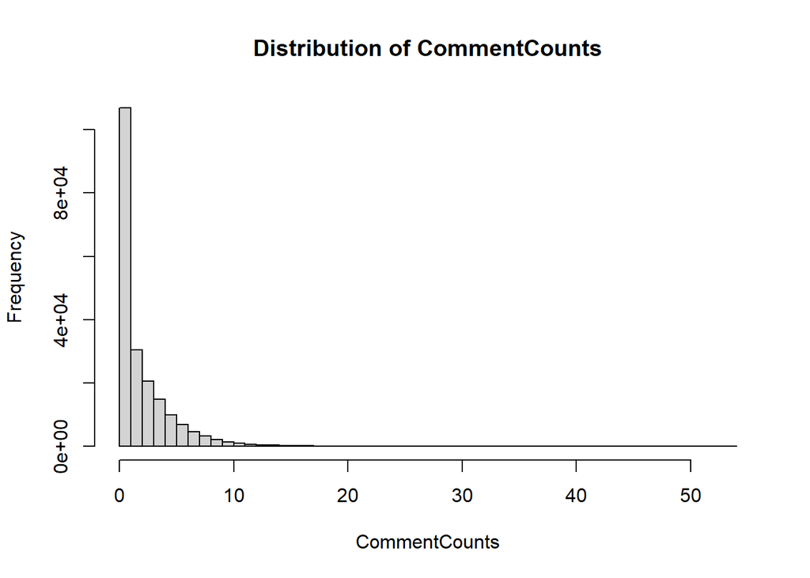

```r
comment_distribution <- dbGetQuery(db, "SELECT Id, CommentCount FROM Posts WHERE PostTypeId = 1 ORDER BY CommentCount DESC")


hist(comment_distribution$CommentCount, breaks = 50,
     main = "Distribution of CommentCounts",
     xlab = "CommentCounts", ylab = "Frequency")
```

```r
dbGetQuery(db, "SELECT COUNT(Id) FROM Posts WHERE CommentCount > 0 and PostTypeId = 1")
```

```
##   COUNT(Id)
## 1    128280
```

## Required Questions

21. Compute the table that contains • the question, • the name of the user who posted it, • when that user joined, • their location • the date the question was first posted, • the accepted answer, • when the accepted answer was posted • the name of the user who provided the accepted answer.

Although it is more computationally expensive to do, I like to break up questions like this into multiple parts. Since the Posts table contains both the questions and the answers, I create two separate tables and join them together for our final result.

The first table that we create combines Question info with the user who posted the question’s account information. The second table combines the Answer info with the user who posted the answer’s account information.

Lastly, we use a left join to combine the two tables. It is important to note that this returns all of matches that our question table has with the answer table. Therefore, any questions that do not have an accepted answer are left out of this table. This question was left ambiguous as to if we wanted to include questions without an accepted answer, so we will work with the interpretation that we only want questions with accepted answers in this table.

There are 201,001 questions posted by non-deleted users, and 66,213 have accepted answers.

```r
question_info <- dbGetQuery(db, "SELECT p.Id as QuestionID, p.Title as QuestionTitle, u.DisplayName as Username, u.Location, p.CreationDate as QuestionPostedDate, u.CreationDate as UserJoinedDate, AcceptedAnswerId
           FROM Posts p, Users u
           WHERE u.Id = p.OwnerUserId and
           p.PostTypeId = 1
           ")
nrow(question_info)
```

```
## [1] 201001
```

```r
answer_info <- dbGetQuery(db, "SELECT p.Id as AnswerID, p.Body as Answer, p.CreationDate as AnswerPostedDate, u.DisplayName as AnswerUsername
           FROM Posts p, Users u
           WHERE u.Id = p.OwnerUserId and
           p.PostTypeId = 2")

dbWriteTable(db, "question_info", question_info, overwrite = TRUE)
dbWriteTable(db, "answer_info", answer_info, overwrite = TRUE)

qna <- dbGetQuery(db, "SELECT q.QuestionTitle, q.Username, q.UserJoinedDate, q.Location, q.QuestionPostedDate,
          a.Answer, a.AnswerPostedDate, a.AnswerUsername
          FROM question_info q
          LEFT JOIN answer_info a
          WHERE AcceptedAnswerId = AnswerID
          ")
head(qna, n = 1)
```

```
##                   QuestionTitle    Username          UserJoinedDate
## 1 Eliciting priors from experts csgillespie 2010-07-19T19:04:52.280
##                    Location      QuestionPostedDate
## 1 Newcastle, United Kingdom 2010-07-19T19:12:12.510
##                                                                                                                                                                                                                                                                                                          …
## 1 <p>John Cook gives some interesting recommendations. Basically, get percentiles/quantiles (not means or obscure scale parameters!) from the experts, and fit them with the appropriate distribution.</p>\\\\n\\\\n<p><a href="http://www.johndcook.com/blog/2010/01/31/parameters-from-percentiles/">ht…
##          AnswerPostedDate AnswerUsername
## 1 2010-07-19T19:19:46.160         Harlan
```

```r
nrow(qna)
```

```
## [1] 66213
```

22. Determine the users that have only posted questions and never answered a question? (Compute the table containing the number of questions, number of answers and the user’s login name for this group.) How many are there?

My philosophy: go to Posts table, group by OwnerUserId and count the total number of posts by PostType = 1. Then, we will do the same by PostType = 2. Then, we will look for User IDs that are in the first table, but are NOT in the second table. Lastly, we will do an inner join with the user table to get their login name; by doing this, we also filter out the deleted users with blank user IDs as they do not have an associated username.

From this, we find out that there are 76,410 users that have posted a question that have not answered a question.

```r
question_count <- dbGetQuery(db, "SELECT OwnerUserId, COUNT(*) as QuestionCount FROM Posts WHERE PostTypeId = 1 GROUP BY OwnerUserId  ORDER BY COUNT(*) DESC ")
answer_count <- dbGetQuery(db, "SELECT OwnerUserId, COUNT(*) as AnswerCount FROM Posts WHERE PostTypeId = 2 GROUP BY OwnerUserId  ORDER BY COUNT(*) DESC ")
dbWriteTable(db, "question_count", question_count, overwrite = TRUE)
dbWriteTable(db, "answer_count", answer_count, overwrite = TRUE)

q22_final <- (dbGetQuery(db, "SELECT q.OwnerUserId, q.QuestionCount, u.DisplayName
  FROM question_count q
  LEFT JOIN answer_count a ON q.OwnerUserId = a.OwnerUserId
  INNER JOIN Users u ON q.OwnerUserId = u.Id
  WHERE a.OwnerUserId IS NULL"))
head(q22_final)
```

```
##   OwnerUserId QuestionCount DisplayName
## 1      108150           236  user321627
## 2      241460           133   The Great
## 3       12329           128   user34790
## 4       67137           121        Dave
## 5       42198           109         TEX
## 6       45971           101      Adrian
```

```r
nrow(q22_final)
```

```
## [1] 76410
```

23. Compute the table with information for the 75 users with the most accepted answers. This table should include • the user’s display name, • creation date, • location, • the number of badges they have won, – the names of the badges (as a single string) • the dates of the earliest and most recent accepted answer (as two fields) – the (unique) tags for all the questions for which they had the accepted answer (as a single string)

This question was super difficult! It really tested the bounds of my knowledge. While I initially thought I could do much of this problem in one go, I had to go back to my previous method of breaking it up into chunks.

I went head-on into this problem simply using the answer_count table at first. However, I realized around halfway into this question that I did not implement a method to check that the answer was an accepted answer. The solution that I decided on involved matching the Id of the answer Post to the AcceptedAnswerId of the question by using the ParentId. The ParentId provides the question that the answer solves, so we do a subquery to find the AAI when for matches between Id and ParentId. This gives us our primary table, accepted_answer_count.

The first variables are fairly standard. We use GROUP_CONCAT for the badge names as it was suggested on Piazza. For finding the dates, I used ChatGPT to help with the conversion formula from String to Date. We use this subquery method for ParentId here as well because it was at this step that I realized we were not checking for accepted answers.

For the Distinct Tags, we used GROUP_CONCAT as before in conjunction with our previous methods. We connect our answers to their associated question’s tags using the Parent Tag as before.

My final output will only show one row because each row has a lot of tags and badge names.

```r
accepted_answer_count <- dbGetQuery(db, "SELECT p.OwnerUserId, COUNT(*) as AnswerCount FROM Posts p
                          WHERE p.PostTypeId = 2 and p.Id =
                          (SELECT AcceptedAnswerId from Posts WHERE Id = p.ParentId)
                           GROUP BY OwnerUserId
                           ORDER BY COUNT(*) DESC ")
dbWriteTable(db, "accepted_answer_count", accepted_answer_count, overwrite = TRUE)

distinct_tags <- dbGetQuery(db, "SELECT p.OwnerUserId, GROUP_CONCAT(DISTINCT t.Tag) as DistinctTags  FROM Posts p
                          LEFT JOIN TagPosts t on p.ParentId = t.Id
                          WHERE p.PostTypeId = 2 and p.Id =
                          (SELECT AcceptedAnswerId from Posts WHERE Id = p.ParentId)
                           GROUP BY OwnerUserId
                           ORDER BY COUNT(*) DESC ")
dbWriteTable(db, "distinct_tags", distinct_tags, overwrite = TRUE)


intermediary <- dbGetQuery(db, "SELECT a.OwnerUserId, a.AnswerCount, u.DisplayName, u.CreationDate, u.Location, COUNT(b.Class) as BadgeCount, GROUP_CONCAT(DISTINCT b.Name) as BadgeNames
  FROM accepted_answer_count a
  LEFT JOIN Badges b on a.OwnerUserId = b.UserId
  INNER JOIN Users u ON a.OwnerUserId = u.Id
  GROUP BY OwnerUserId, DisplayName
  ORDER BY AnswerCount DESC")

dbWriteTable(db, "intermediary", intermediary, overwrite = TRUE)


#Conversion format provided to me via ChatGPT; I did not know how to convert it to a date without it simply converting the year (as I did in one of the earlier questions).

creationdates <- dbGetQuery(db, "SELECT u.OwnerUserId,
       MIN(strftime('%Y-%m-%d %H:%M:%S', p.CreationDate)) AS FirstPostDate,
       MAX(strftime('%Y-%m-%d %H:%M:%S', p.CreationDate)) AS LastPostDate
FROM accepted_answer_count u
LEFT JOIN Posts p ON u.OwnerUserId = p.OwnerUserId
WHERE PostTypeId = 2 and p.Id = (SELECT AcceptedAnswerId from Posts
                                WHERE Id = p.ParentId)
GROUP BY u.OwnerUserId
ORDER BY u.AnswerCount DESC")

dbWriteTable(db, "creationdates", creationdates, overwrite = TRUE)


head(dbGetQuery(db, "SELECT i.*, c.FirstPostDate, c.LastPostDate, d.DistinctTags
           FROM intermediary i, creationdates c, distinct_tags d
           WHERE i.OwnerUserId = c.OwnerUserId and i.OwnerUserId = d.OwnerUserId
           ORDER BY i.AnswerCount DESC
           LIMIT 75"), n = 1)
```

```
##   OwnerUserId AnswerCount DisplayName            CreationDate       Location
## 1         805        2335      Glen_b 2010-08-07T08:40:07.287 I'm right here
##   BadgeCount
## 1       1605
##                                                                                                                                                                                                                                                                                                          …
## 1 Altruist,Analytical,Announcer,Archaeologist,Autobiographer,Benefactor,Booster,Caucus,Citizen Patrol,Civic Duty,Cleanup,Commentator,Constituent,Convention,Copy Editor,Critic,Curious,Custodian,Deputy,Disciplined,Editor,Electorate,Enlightened,Enthusiast,Epic,Excavator,Explainer,Famous Question,Fan…
##         FirstPostDate        LastPostDate
## 1 2010-08-09 00:37:45 2023-02-23 22:11:02
##                                                                                                                                                                                                                                                                                                          …
## 1 dice,games,probability,generalized-linear-model,heteroscedasticity,negative-binomial-distribution,overdispersion,poisson-distribution,multivariate-analysis,normal-distribution,chi-squared-test,trend,dataset,modeling,polynomial,r-squared,regression,anova,spss,mean,moments,maximum-likelihood,self…
```

24. How many questions received no answers (accepted or unaccepted)? How many questions had no accepted answer?

From number 21, there are 201,001 questions posted by non-deleted users, and 66,213 have accepted answers posted by non-deleted users.

According to this calculation, 134,788 questions do not have an accepted answer. If we do a direct computation (as we do below), we find that 136,365 questions do not have an accepted answer. We will use the latter number as some data may have been lost in the joining process of the previous calculation.

In order to find the questions with no answer at all, we will look for matches between Question Id’s and the Parent Id’s of answers. If there are Question IDs that do not have any matching Parent IDs, then that question has no unaccepted answers.

```r
dbGetQuery(db, "SELECT COUNT(Id) FROM Posts
           WHERE PostTypeId = 1 AND AcceptedAnswerId = ''
           AND Id != '' ")
```

```
##   COUNT(Id)
## 1    136365
```

```r
 dbGetQuery(db, "SELECT COUNT(Id) FROM Posts
              WHERE PostTypeId = 1 AND
              Id NOT IN (
                SELECT ParentId FROM Posts
              )
            ")
```

```
##   COUNT(Id)
## 1     66970
```

There are 66,970 questions that do not have any answers. Alternatively, we can also just count posts where AnswerCount = 0.

```r
 dbGetQuery(db, "SELECT COUNT(Id) FROM Posts
              WHERE PostTypeId = 1 AND
              AnswerCount = 0
            ")
```

```
##   COUNT(Id)
## 1     66970
```

25. What is the distribution of answers per posted question?

From the last question, we already know that there are many questions that are left unanswered. However, many intriguing posts also garner multiple answers. Therefore, the average number of answers across all posts is just under 1 at 0.9684787.

There is one question that got 153 different answers. I was intrigued, and I found that it was a post asking for people’s favorite statistic’s quotes.

If we convert our AnswerCount into a table, we can clearly see the distribution laid out. The vast majority are at the frontend of the distribution, with either 0, 1, or 2 answers. We use a log-adjust graph in order to visibly display all of our data on one graph. It is very important to make note of the y-axis as it changes dramatically over a small distance. We can see that the first three entries that go above the last bar are well above 10,000, and the second bar is very close to reaching 100,000.

In comparison, the next most frequent value, 3 answers, occurs only 7,246 across all posts. This quickly decreases to 2408, 905, 401, 210, 136, 82, and finally only 62 occurences of a post receiving 10 answers.

```r
answer_distribution <- dbGetQuery(db, "SELECT Id, AnswerCount FROM Posts
              WHERE PostTypeId = 1
              ORDER BY AnswerCount DESC
            ")

dbGetQuery(db, "SELECT AVG(AnswerCount) FROM Posts WHERE PostTypeId = 1")
```

```
##   AVG(AnswerCount)
## 1        0.9684787
```

```r
counts <- table(answer_distribution$AnswerCount)
counts
```

```
##
##     0     1     2     3     4     5     6     7     8     9    10    11    12
## 66970 98602 27191  7246  2408   905   401   210   136    82    62    35    25
##    13    14    15    16    17    18    19    20    21    22    23    24    25
##    19    14    14     8     5     4     5     1     5     2     1     1     2
##    26    27    28    31    32    34    37    38    46    47    78    80   153
##     2     1     2     1     2     1     1     1     1     1     1     1     1
```

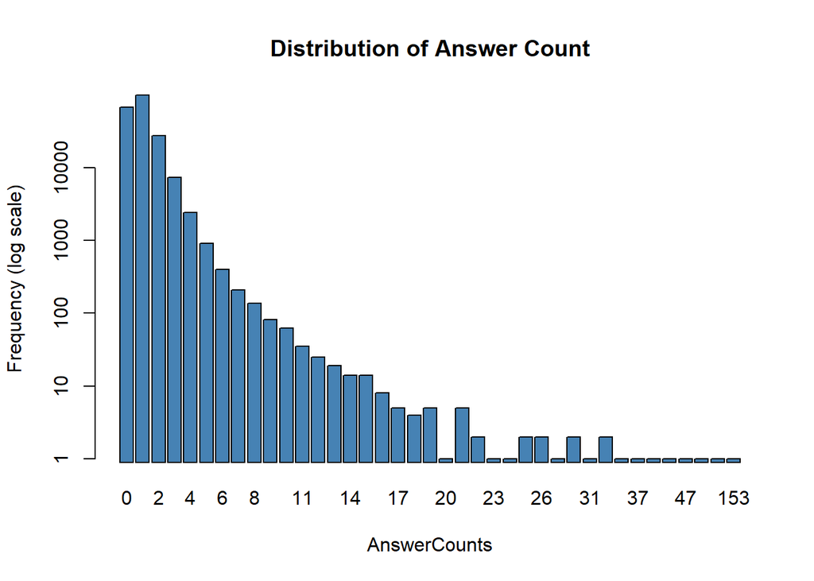

```r
barplot(counts, log = "y", col = "steelblue", main = "Distribution of Answer Count",
        xlab = "AnswerCounts", ylab = "Frequency (log scale)")
```

26. What is the length of time for a question to receive an answer? to obtaining an accepted answer?

First, we create tables with the times for Question creation date and answer creation date and join them together based on ParentId and Question ID.

In the full table that we create, we have multiple answers submitted for each question. We want only the first response for each question. After scavenging through StackOverFlow, I found that we can achieve this via partitioning by order of AnswerPosted. This ranks each possible response. We then can select only the first row.

We find the difference between each time in seconds, and divide by 60 to get the difference in minutes in between question posting and the first answer being posted.

To get the first accepted answer, it is a bit easier. We simply find the entry where the AcceptedAnswerId matches one of the Answer IDs, and compute the difference similarly.

```r
q_time <- dbGetQuery(db, "SELECT Id as QId, AcceptedAnswerId, (strftime('%Y-%m-%d %H:%M:%S', p.CreationDate)) AS QuestionPosted
           FROM Posts p
           WHERE PostTypeId = 1")
a_time <- dbGetQuery(db, "SELECT p.Id as AId, p.ParentId, (strftime('%Y-%m-%d %H:%M:%S', p.CreationDate)) AS AnswerPosted
           FROM Posts p
           WHERE PostTypeId = 2
           ")

dbWriteTable(db, "q_time", q_time, overwrite = TRUE)
dbWriteTable(db, "a_time", a_time, overwrite = TRUE)

fullresults_qa <- dbGetQuery(db, "SELECT q.*, a.* FROM q_time q, a_time a
           WHERE a.ParentId = q.QId
           ")

dbWriteTable(db, "fullresults_qa", fullresults_qa, overwrite = TRUE)


first_answer <- dbGetQuery(db, "SELECT QId, AcceptedAnswerId, AId, (strftime('%s', AnswerPosted) - strftime('%s', QuestionPosted))/60 as MinutesUntilFirstAnswer
FROM (
    SELECT QId, AcceptedAnswerId, QuestionPosted, AId, ParentId, AnswerPosted,
           ROW_NUMBER() OVER (PARTITION BY QId ORDER BY AnswerPosted) AS rn
    FROM fullresults_qa
) AS sub WHERE rn = 1")

head(first_answer)
```

```
##   QId AcceptedAnswerId AId MinutesUntilFirstAnswer
## 1   1               15  15                       7
## 2   2               59  20                      11
## 3   3                5   5                       1
## 4   4              135 133                     138
## 5   6                0  13                       4
## 6   7               18  12                       2
```

```r
first_accepted <- dbGetQuery(db, "SELECT QId, AcceptedAnswerId, (strftime('%s', AnswerPosted) - strftime('%s', QuestionPosted))/60 as MinutesUntilAcceptedAnswer
           FROM fullresults_qa WHERE AId = AcceptedAnswerId")
head(first_accepted)
```

```
##   QId AcceptedAnswerId MinutesUntilAcceptedAnswer
## 1   1               15                          7
## 2   2               59                         30
## 3   3                5                          1
## 4   4              135                        142
## 5   7               18                          8
## 6  10             1887                      44082
```

27. How many answers are typically received before the accepted answer?

Here, we will do a self join in order to calculate how many answers are typically submitted for each question before the accepted answer is received. We check for when AcceptedAnswerId != 0 as these questions do not have an accepted answer. We want to find areas when t2.AI is NULL as it when it does not equal the accepted answer. We subtract the Count by 1 as it always has an extra value.

We find that on average, a question has 0.263 answers submitted before the submitted answer is provided. This means that typically, the first answer is the accepted answer for most questions.

```r
numbefore <- dbGetQuery(db, "SELECT t1.QId, (COUNT(*)-1) AS NumRowsBeforeAccepted
FROM fullresults_qa t1
LEFT JOIN fullresults_qa t2 ON t1.QId = t2.QId AND t2.AId = t1.AcceptedAnswerId
WHERE (t2.AId IS NULL OR t2.AId > t1.AId) AND t1.AcceptedAnswerId != 0
GROUP BY t1.QId;")

dbWriteTable(db, "numbefore", numbefore, overwrite = TRUE)
dbGetQuery(db, "SELECT AVG(NumRowsBeforeAccepted) FROM numbefore")
```

```
##   AVG(NumRowsBeforeAccepted)
## 1                  0.2629184
```